#### Statistics for Laboratory Scientists ( 140.615 )

## Analysis of Variance - Multiple Comparisons - Advanced

#### Example from class: pea sections and sugar

Imagine you want to compare all treatment levels to the control group only. There is a procedure for that called Dunnett’s test, that does that efficiently.

First, read in the data, make a plot, and carry out the ANOVA.

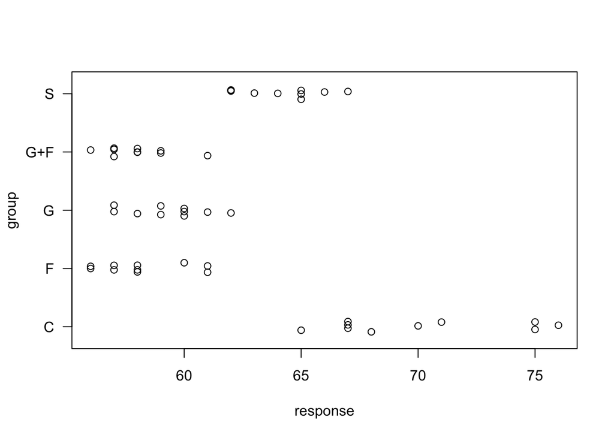

```r
x <- c(75,67,70,75,65,71,67,67,76,68,
       57,58,60,59,62,60,60,57,59,61,
       58,61,56,58,57,56,61,60,57,58,
       58,59,58,61,57,56,58,57,57,59,
       62,66,65,63,64,62,65,65,62,67)
treat <- factor(rep(c("C","G","F","G+F","S"), rep(10,5)))
sugar <- data.frame(rsp=x, trt=treat)

set.seed(1)
par(las=1)
stripchart(sugar$rsp ~ sugar$trt, method="jitter", pch=1, xlab="response", ylab="group")
```

```r
aov.out <- aov(rsp ~ trt, data=sugar)
summary(aov.out)
```

```
##             Df Sum Sq Mean Sq F value   Pr(>F)
## trt          4 1077.3  269.33   49.37 6.74e-16 ***
## Residuals   45  245.5    5.46
## ---
## Signif. codes:  0 '***' 0.001 '**' 0.01 '*' 0.05 '.' 0.1 ' ' 1
```

The procedure for Dunnett’s test is not in the base distribution, but in an add-on package called ‘multcomp’.

https://cran.r-project.org/web/packages/multcomp/index.html

When you use this package for the first time, uncomment the first line to install the package. The ‘library’ function then adds the package to your workspace.

```r
# install.packages("multcomp")
library("multcomp")
```

We then use the ‘glht’ function (general linear hypotheses testing) and specify we want Dunnett’s test for the multiple comparisons procedure.

```r
g.out <- glht(aov.out, linfct=mcp(trt="Dunnett"))
summary(g.out)
```

```
##
##   Simultaneous Tests for General Linear Hypotheses
##
## Multiple Comparisons of Means: Dunnett Contrasts
##
##
## Fit: aov(formula = rsp ~ trt, data = sugar)
##
## Linear Hypotheses:
##              Estimate Std. Error t value Pr(>|t|)
## F - C == 0    -11.900      1.045 -11.392  < 1e-06 ***
## G - C == 0    -10.800      1.045 -10.339  < 1e-06 ***
## G+F - C == 0  -12.100      1.045 -11.584  < 1e-06 ***
## S - C == 0     -6.000      1.045  -5.744  1.7e-06 ***
## ---
## Signif. codes:  0 '***' 0.001 '**' 0.01 '*' 0.05 '.' 0.1 ' ' 1
## (Adjusted p values reported -- single-step method)
```

By default, R uses the first level of the specified factor as the comparison group, which in our case was ‘C’, the control group.

```r
str(sugar)
```

```
## 'data.frame':    50 obs. of  2 variables:
##  $ rsp: num  75 67 70 75 65 71 67 67 76 68 ...
##  $ trt: Factor w/ 5 levels "C","F","G","G+F",..: 1 1 1 1 1 1 1 1 1 1 ...
```

```r
levels(sugar$trt)
```

```
## [1] "C"   "F"   "G"   "G+F" "S"
```

If you (for example) want to compare all groups to the mixed sugar group, we first have to re-order the factor levels.

```r
sugar$trt <- relevel(sugar$trt, "G+F")
str(sugar)
```

```
## 'data.frame':    50 obs. of  2 variables:
##  $ rsp: num  75 67 70 75 65 71 67 67 76 68 ...
##  $ trt: Factor w/ 5 levels "G+F","C","F",..: 2 2 2 2 2 2 2 2 2 2 ...
```

```r
levels(sugar$trt)
```

```
## [1] "G+F" "C"   "F"   "G"   "S"
```

Re-run the analysis.

```r
aov.out <- aov(rsp ~ trt, data=sugar)
summary(aov.out)
```

```
##             Df Sum Sq Mean Sq F value   Pr(>F)
## trt          4 1077.3  269.33   49.37 6.74e-16 ***
## Residuals   45  245.5    5.46
## ---
## Signif. codes:  0 '***' 0.001 '**' 0.01 '*' 0.05 '.' 0.1 ' ' 1
```

```r
g.out <- glht(aov.out, linfct=mcp(trt="Dunnett"))
summary(g.out)
```

```
##
##   Simultaneous Tests for General Linear Hypotheses
##
## Multiple Comparisons of Means: Dunnett Contrasts
##
##
## Fit: aov(formula = rsp ~ trt, data = sugar)
##
## Linear Hypotheses:
##              Estimate Std. Error t value Pr(>|t|)
## C - G+F == 0   12.100      1.045  11.584   <1e-04 ***
## F - G+F == 0    0.200      1.045   0.191    0.999
## G - G+F == 0    1.300      1.045   1.245    0.543
## S - G+F == 0    6.100      1.045   5.840   <1e-04 ***
## ---
## Signif. codes:  0 '***' 0.001 '**' 0.01 '*' 0.05 '.' 0.1 ' ' 1
## (Adjusted p values reported -- single-step method)
```